# Lending_Club

Santiago Torres

December 18, 2016

# Read data

```r
defaults <- read.csv('cleaned_up.csv')
summary(defaults$loan_status)
```

```
##        Charged Off            Current            Default
##               5658                201                  1
##         Fully Paid    In Grace Period  Late (16-30 days)
##              33902                  9                  5
## Late (31-120 days)
##                 10
```

I only care if a loan has been charged off or defaulted so i will drop the values that arent current, fully paid, charged off, or default

```r
keep <- defaults$loan_status %in% c('Charged Off', 'Current', 'Default', 'Fully Paid')
ndefaults <- defaults[keep, ]
binaryResponse <- mapply(function(x) {
  x %in% c('Current','Fully Paid')
  }, ndefaults$loan_status)
ndefaults$loan_status <- binaryResponse
summary(ndefaults$loan_status)
```

```
##    Mode   FALSE    TRUE    NA's
## logical    5659   34103       0
```

These are all individual accounts that meet Lending Club’s policies with initial listing status - F not on a payment plan

I want to predict False in loan_status

## Response

`loan_status` - Categorical response with 2 levels:

```
{
True: Loan is current or fully paid
False: Loan is charged off or in default
}
```

## Predictors

```r
names(ndefaults)
```

```
##  [1] "loan_amnt"               "funded_amnt"
##  [3] "funded_amnt_inv"         "term"
##  [5] "int_rate"                "installment"
##  [7] "grade"                   "sub_grade"
##  [9] "emp_title"               "emp_length"
## [11] "home_ownership"          "annual_inc"
## [13] "verification_status"     "issue_d"
## [15] "loan_status"             "desc"
## [17] "purpose"                 "title"
## [19] "zip_code"                "addr_state"
## [21] "dti"                     "delinq_2yrs"
## [23] "earliest_cr_line"        "fico_range_low"
## [25] "fico_range_high"         "inq_last_6mths"
## [27] "mths_since_last_delinq"  "mths_since_last_record"
## [29] "open_acc"                "pub_rec"
## [31] "revol_bal"               "revol_util"
## [33] "total_acc"               "out_prncp"
## [35] "out_prncp_inv"           "total_pymnt"
## [37] "total_pymnt_inv"         "total_rec_prncp"
## [39] "total_rec_int"           "total_rec_late_fee"
## [41] "recoveries"              "collection_recovery_fee"
## [43] "last_pymnt_d"            "last_pymnt_amnt"
## [45] "next_pymnt_d"            "last_credit_pull_d"
## [47] "last_fico_range_high"    "last_fico_range_low"
```

```r
length(names(ndefaults))
```

```
## [1] 48
```

We still have a lot of predictors here lets try to consolidate some of them

### Quantitative

`loan_amt` `int_rate` `installment` `annual_inc` `dti` `delinq_2yrs` `earliest_cr_line` (length of time) `fico_range_low` `fico_range_high` (take avg) `inq_last_6mths` `mths_since_last_delinq` `mths_since_last_record` `open_acc` `pub_rec` `revol_util` `total_acc`

We only need one predictor representing the loan amount to avoid multicollinearity

```r
ndefaults$funded_amnt <- NULL
ndefaults$funded_amnt_inv <- NULL
```

Drop `revol_bal` because `revol_util` is a better representation of usage (ratio)

```r
ndefaults$revol_bal <- NULL
```

We will average FICO scores when they got the loan

### Categorical

`term` { 36 months 60 months } make sure to factor categorical variables

```r
ndefaults$term <- factor(ndefaults$term)
```

`emp_title` is outside the scope of our investigation since it would require text analysis; `desc` and `title` are also out of scope.

```r
ndefaults$emp_title <- NULL
ndefaults$desc <- NULL
ndefaults$title <- NULL
```

`grade` `subgrade` * `emp_length`

- `home_ownership`
- Rent; Mortgage; Own

`verification_status` `issue_d` `purpose` `zip_code` is a more granular version of `addr_state`

```r
ndefaults$zip_code <- NULL
```

`addr_state`

Whittling down predictors gets harder so it is time to begin some analysis

Quantitative `loan_amt` `int_rate` `installment` `annual_inc`

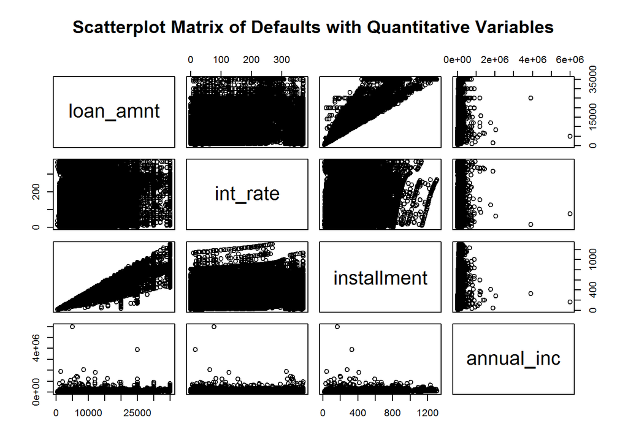

```r
pairs(~ loan_amnt + int_rate + installment + annual_inc, data=ndefaults, main="Scatterplot Matrix of Defaults with Quantitative Variables")
```

`dti` `delinq_2yrs` `earliest_cr_line` (length of time) `fico_range_low` `fico_range_high` (take avg) `inq_last_6mths` `mths_since_last_delinq` `mths_since_last_record` `open_acc` `pub_rec` `revol_util` `total_acc`

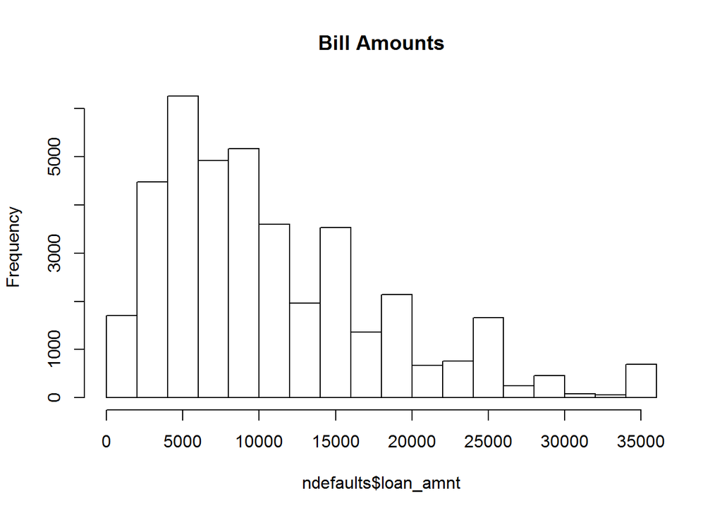

```r
hist(ndefaults$loan_amnt, main="Bill Amounts")
```